# JHU DS Course 8 Project

Jingting Lu

April 4, 2017

## Identifying body movement based on accelerometer measurements

Introduction

Using devices such as Jawbone Up, Nike FuelBand, and Fitbit it is now possible to collect a large amount of data about personal activity relatively inexpensively.

In this project, we used data from accelerometers on the belt, forearm, arm, and dumbell of 6 participants. They were asked to perform barbell lifts correctly and incorrectly in 5 different ways. We trained a model to learn to identify the way participants performed the movements. The model was able to correctly identify the movement of all 20 test samples.

### Step 1 Download and import data

```r
url1 <- "https://d396qusza40orc.cloudfront.net/predmachlearn/pml-training.csv"
url2 <- "https://d396qusza40orc.cloudfront.net/predmachlearn/pml-testing.csv"
dest1 <- "C:\\Users\\jingting.lu\\Desktop\\JHU_Data science\\8_Practical machine learning\\pml-training.csv"
dest2 <- "C:\\Users\\jingting.lu\\Desktop\\JHU_Data science\\8_Practical machine learning\\pml-testing.csv"

if(!file.exists(dest1)){download.file(url1, dest1)}
if(!file.exists(dest2)){download.file(url2, dest2)}

train<-read.csv(dest1, header = T, na.strings=c('#DIV/0!', '', 'NA'))
test<-read.csv(dest2, header = T, na.strings=c('#DIV/0!', '', 'NA'))
```

But we do worry about NAs

```r
dim(train)
```

```
## [1] 19622   160
```

```r
sum(is.na(train))
```

```
## [1] 1925102
```

```r
sum(complete.cases(train))
```

```
## [1] 0
```

```r
max(apply(train, 2, function(x) sum(is.na(x))))
```

```
## [1] 19622
```

```r
NAPerCol <- apply(train, 2, function(x) sum(is.na(x)))/nrow(train)

train <- train[,NAPerCol < 0.95]
train<-train[,-c(1:7)]
test <- test[,NAPerCol < 0.95]
test<-test[,-c(1:7)]
ncol(train)
```

```
## [1] 53
```

We also checked for zero covariates and found out that there is none.

```r
#Example
nzv <- nearZeroVar(train, saveMetrics = T)
sum(nzv$nzv)
```

```
## [1] 0
```

We will test for highly correlated variables

```r
descrCor <-  cor(train[,-53])
sum(abs(descrCor[upper.tri(descrCor)]) > .99)
```

```
## [1] 1
```

```r
which(abs(descrCor[upper.tri(descrCor)]) > .99)
```

```
## [1] 37
```

We see that there is only one pair of variables with more than 99% correlation. Let’s keep it for now and visualize all the correlation between variables.

## Visualize data

Given the dimension of this dataset, direct visualization is difficult - but we can show the correlation between variables.

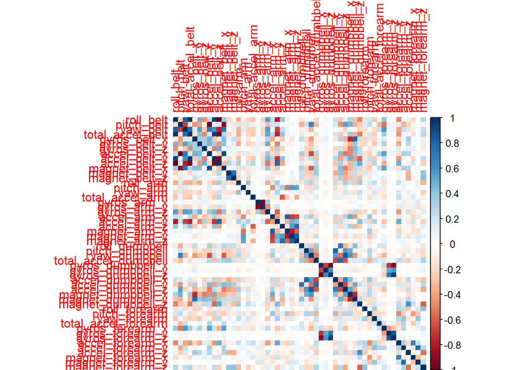

```r
library(corrplot)
corrPlot <- cor(train[, -53])
corrplot(corrPlot, method="color")
```

### Preprocess data

We will preprocess data to center and scale

```r
#Standardizing the dataset
set.seed(1)
pre_obj<-preProcess(train[,-53],method = c("center","scale"))
train_proc <- predict(pre_obj,train[,-53])
test_proc<-predict(pre_obj,test[,-53])
train_proc$classe <- train[,53]
test_proc$classe <- test[,53]
```

We then train a random forest model to classify the movement. Random forest is one of the most accurate and widely used classification algorithms, and it works efficiently on datasets with many variables.

### Train Random forest model

```r
set.seed(1)
require(parallel)
require(doParallel)
cl <- makeCluster(detectCores() - 1)
registerDoParallel(cl)

system.time(trainingModel <- train(classe ~ ., data=train_proc,
                                   method="rf",
                                   ntree = 250,
                                   trControl = trainControl(
                                       method = "cv",
                                       number = 10,
                                       classProbs = T,
                                       savePredictions = T,
                                       allowParallel = T)))
```

```
##    user  system elapsed
##  104.05    1.53  597.66
```

```r
stopCluster(cl)
```

```r
trainingModel
```

```
## Random Forest
##
## 19622 samples
##    52 predictor
##     5 classes: 'A', 'B', 'C', 'D', 'E'
##
## No pre-processing
## Resampling: Cross-Validated (10 fold)
## Summary of sample sizes: 17659, 17660, 17660, 17660, 17659, 17659, ...
## Resampling results across tuning parameters:
##
##   mtry  Accuracy   Kappa
##    2    0.9949545  0.9936178
##   27    0.9948018  0.9934245
##   52    0.9897053  0.9869772
##
## Accuracy was used to select the optimal model using  the largest value.
## The final value used for the model was mtry = 2.
```

CM for trainingset

```r
confusionMatrix(predict(trainingModel$finalModel, train_proc[,-53]),train_proc$classe)
```

```
## Confusion Matrix and Statistics
##
##           Reference
## Prediction    A    B    C    D    E
##          A 5580    0    0    0    0
##          B    0 3797    0    0    0
##          C    0    0 3422    0    0
##          D    0    0    0 3216    0
##          E    0    0    0    0 3607
##
## Overall Statistics
##
##                Accuracy : 1
##                  95% CI : (0.9998, 1)
##     No Information Rate : 0.2844
##     P-Value [Acc > NIR] : < 2.2e-16
##
##                   Kappa : 1
##  Mcnemar's Test P-Value : NA
##
## Statistics by Class:
##
##                      Class: A Class: B Class: C Class: D Class: E
## Sensitivity            1.0000   1.0000   1.0000   1.0000   1.0000
## Specificity            1.0000   1.0000   1.0000   1.0000   1.0000
## Pos Pred Value         1.0000   1.0000   1.0000   1.0000   1.0000
## Neg Pred Value         1.0000   1.0000   1.0000   1.0000   1.0000
## Prevalence             0.2844   0.1935   0.1744   0.1639   0.1838
## Detection Rate         0.2844   0.1935   0.1744   0.1639   0.1838
## Detection Prevalence   0.2844   0.1935   0.1744   0.1639   0.1838
## Balanced Accuracy      1.0000   1.0000   1.0000   1.0000   1.0000
```

We achieved 10-fold cross-validation error of less than 1%. Because of the cross-validation and the large training set I am fairly confident that high accuracy is not due to overfitting. The in-sample error should be in this case similar to out-of-sample error.

Predict for test set

```r
predict(trainingModel,test_proc[,-53])
```

```
##  [1] B A B A A E D B A A B C B A E E A B B B
## Levels: A B C D E
```

They were all correct, according to the quiz.